# LME Models in Longitudinal Treatment Data

Max Flurie

9/29/2020

# Simple Linear Model vs. Linear Mixed Model

Both models involve fitting data to a “best fit” line based on observations

Example: X=Time, Y= Accuracy; How does naming accuracy change over time?

In both, the goal of the model is to “fit a line” accounting for all observations of the data and minimize residuals (i.e., minimize error in the fitted model)

### Option 1

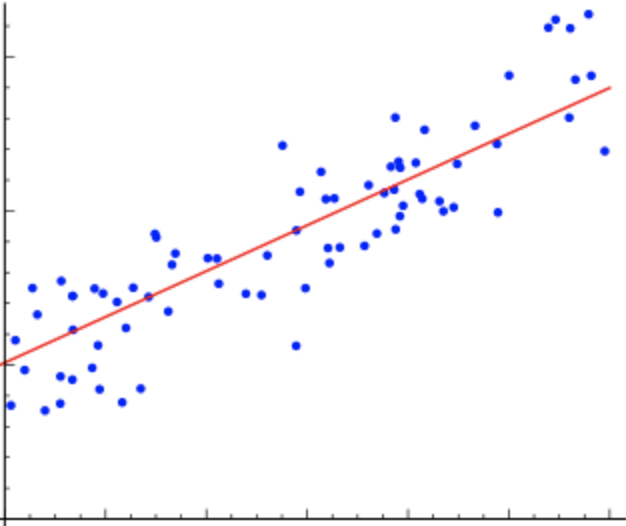

### Option 2

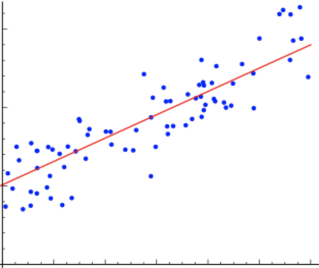

*Linear Regression*

## Simple Linear Model Assumptions

- Assumes Independence (observations are independent of each other, i.e., error is not predictable and errors are uncorrelated)
- Assumes Homoscedasticity (variance of residuals is constant for any value of x)
- Assumes Normal Distribution (y is normally distributed)
- Assumes Linearity (relationship between x ands y is linear)

## Linear Mixed Effects Model Assumptions

Assumptions are much the same, but LME models can account for non-independence using Fixed and Random Effects

### Examples of Non-independent Data

**Nested/Hierarchical Data**

Level 1: Patient, Level 2: Therapist

-Fixed Effect(s): Age, Diagnosis, Treatment Condition

-Random Effect(s): Therapist

**Longitudinal Data**

Level 1: Time, Level 2: Patient

-Fixed Effect(s): Treatment, Time

-Random Effect(s): Patient

### Fixed Effects

These are the predictor variables in the model (e.g., Time, Treatment). Their impact is “fixed” (i.e., constant) across individuals. Fixed effects are measured “without error.”

### Random Effects

In standard linear models, there is only one random effect (i.e., random variance)

Mixed models can account for random variance from more than one source in the data

Random effects (random intercepts here) will allow the performance to vary for each patient

### Option 1

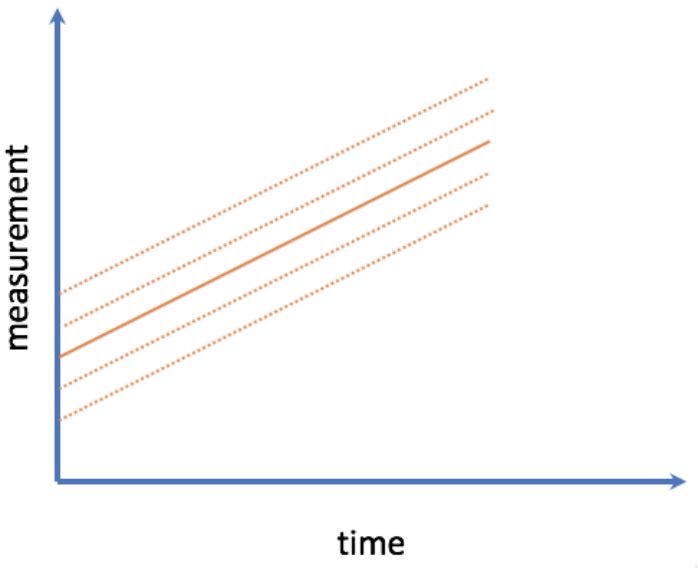

### Option 2

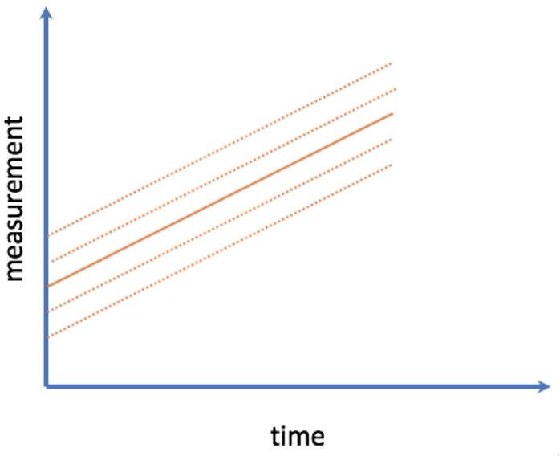

*Random Intercept*

### Why use a LME Model?

**Pros**

-Accounts for nested or longitudinal data

-Robust to (some) missing data

-Can be used with relatively small N (<50)

**Cons**

-Complicated

-More Difficulty to Explain and Interpret

# Using a LME Model in Treatment

```r
library(reshape2)
library(tidyverse)
library(stats)
library(psych)
library(readr)
library(knitr)
library(tibble)
library(readr)
library(outliers)
library(corrplot)
library(magrittr)
library(qwraps2)
library(arsenal)
library(naniar)
library(boot)
library(lme4)
library(lattice)
library(lmerTest)
library(psych)
library(doBy)
library(car)
library(DescTools)
library(sjstats)
library(ggplot2)
library(rstatix)
max.theme <- theme_bw() + theme(axis.line = element_line(colour = "black"), panel.grid.minor = element_blank(), panel.grid.major = element_blank(), panel.border = element_blank(), panel.background = element_blank(), legend.title= element_blank())
```

## Prepare Data

### Import Data

```r
setwd("~/Documents/RData/LME Tutorial")
LexDropMaster<- read_csv("LexDropMaster.csv")
```

### Clean Data

```r
#Remove non-interest variables
Less <-LexDropMaster [-c(1,3,4,5,7,16,18,19,20,22,23,31)]
####Group by Patient, Timepoint, and Condition####
RearrangeLess <- Less %>%
  group_by(Patient, TimePoint, Condition) %>%
  summarize_at(vars(c(1:12)),mean, na.rm=TRUE) ## "na.rm=TRUE" skips over NAs in variable
####Remove T5
RearrangeLess<-subset(RearrangeLess,  TimePoint!="T5")
RearrangeLess
```

```
## # A tibble: 65 x 15
## # Groups:   Patient, TimePoint [37]
##    Patient TimePoint Condition   BNT PPTpics PPTwords  MoCA DigitsF DigitsB
##    <chr>   <chr>     <chr>     <dbl>   <dbl>    <dbl> <dbl>   <dbl>   <dbl>
##  1 S04     T1        control       2      30       14    14       7       5
##  2 S04     T1        train         2      30       14    14       7       5
##  3 S04     T2        control       2      16      NaN    13       6       5
##  4 S04     T2        train         2      16      NaN    13       6       5
##  5 S04     T3        control       1      15       17     9       5       6
##  6 S04     T3        train         1      15       17     9       5       6
##  7 S04     T4        control       1      13       10     5       6       5
##  8 S04     T4        train         1      13       10     5       6       5
##  9 S05     T1        control      11      26       26    15       5       6
## 10 S05     T2        control      12      25       25    16       7       4
## # … with 55 more rows, and 6 more variables: TrailATime <dbl>,
## #   TrailBTime <dbl>, Acc <dbl>, FixationCount <dbl>,
## #   FixationDurationTotal <dbl>, FixationDispersionTotal <dbl>
```

### Summarize Variables of Interest (Table 3)

```r
SummaryStats <-RearrangeLess %>%
  group_by(Condition, TimePoint)%>%
  summarize(mean=mean(Acc, na.rm=TRUE),
            sd=sd(Acc, na.rm=TRUE))
SummaryStats
```

```
## # A tibble: 8 x 4
## # Groups:   Condition [2]
##   Condition TimePoint  mean     sd
##   <chr>     <chr>     <dbl>  <dbl>
## 1 control   T1        0.536 0.137
## 2 control   T2        0.493 0.164
## 3 control   T3        0.454 0.158
## 4 control   T4        0.328 0.185
## 5 train     T1        0.829 0.135
## 6 train     T2        0.924 0.0587
## 7 train     T3        0.901 0.0746
## 8 train     T4        0.816 0.166
```

```r
##Note:Check for missing data
```

## Plot the Data

### Plot the Data: By Group (Fig 1)

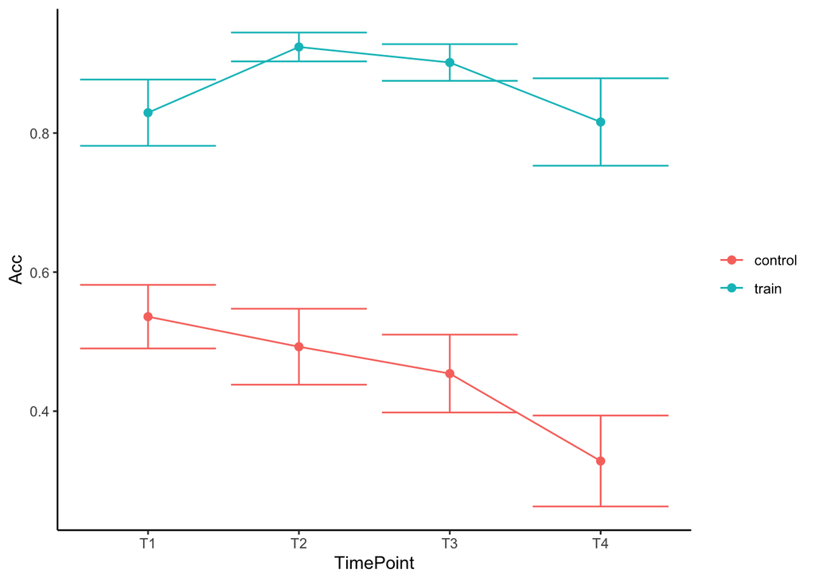

```r
#Across patients
TotalAccMeansPlot2 <- ggplot(RearrangeLess, aes(TimePoint, Acc, color=Condition, fill=Condition)) +
  stat_summary(fun.data = mean_se, geom = "point", size = 2 ) +stat_summary(fun.data = mean_se, geom = "line", size = .5, aes(group = Condition))+ stat_summary(fun.data = mean_se, geom = "errorbar")+max.theme
print(TotalAccMeansPlot2)
```

### Plot the Data: By Participant (Fig 2)

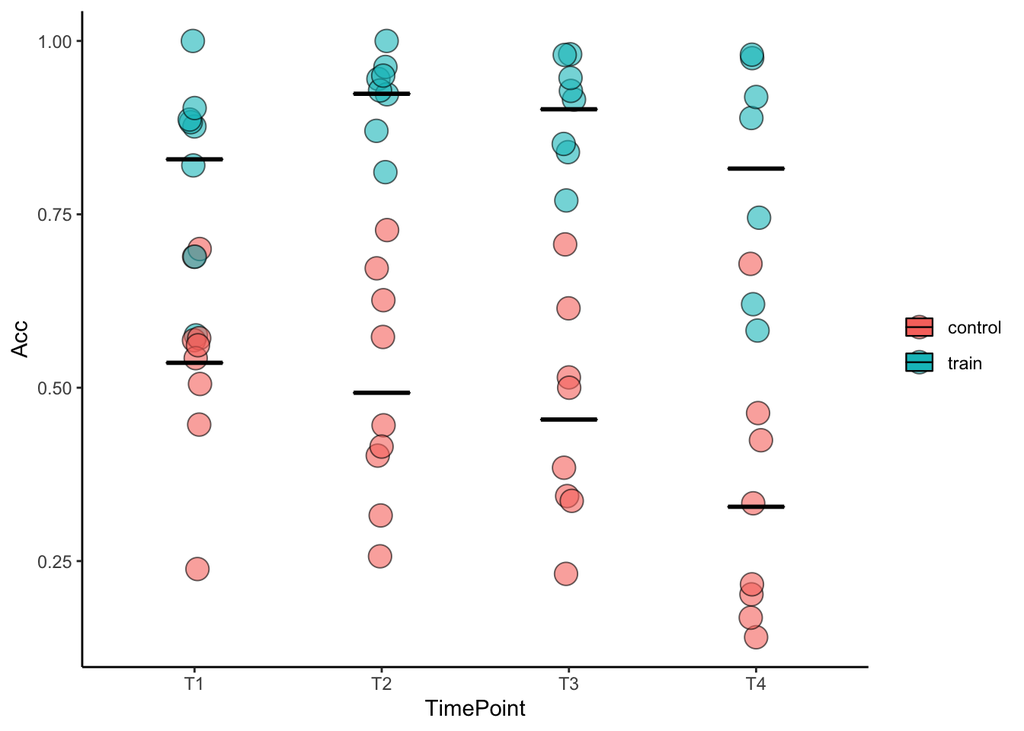

```r
#Each patient
ggplot(RearrangeLess, aes(TimePoint, Acc, shape = TimePoint, fill = Condition)) +
  geom_point(shape = 21, color = "black", size = 5, alpha = 0.6, position = position_jitter(w = 0.03,
h = 0)) + stat_summary(fun.y = mean, fun.ymin = mean, fun.ymax = mean,
geom = "crossbar", color = "black", size = 0.4, width = 0.3) + max.theme
```

## Check Assumptions

### Run Model

```r
betterAccmodel <- lmer(Acc ~ TimePoint + Condition + TimePoint:Condition + (1|Patient), data=RearrangeLess)
```

### Check Normality

```r
outlierTest(betterAccmodel) #Outliers
```

```
## No Studentized residuals with Bonferroni p < 0.05
## Largest |rstudent|:
##    rstudent unadjusted p-value Bonferroni p
## 18 2.296081           0.025579           NA
```

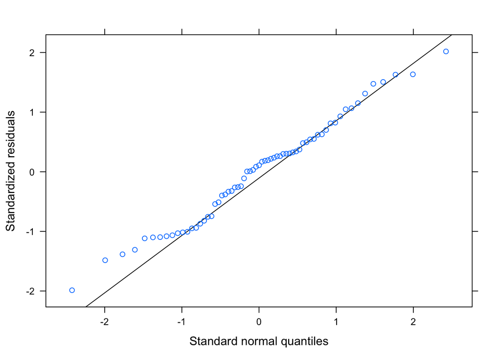

```r
qqmath(betterAccmodel) #Normality
```

```r
#Note: Plot shows observed Residuals (Y) vs. Theoretic (X). If both sets of quantiles are from the same distribution, it should form a fairly straight line. Normality can be fixed with transformations, like in standard linear models.
```